# 第二讲 线性回归

## 4 判断是否存在异常值点

### 4.1 三种点总的判断

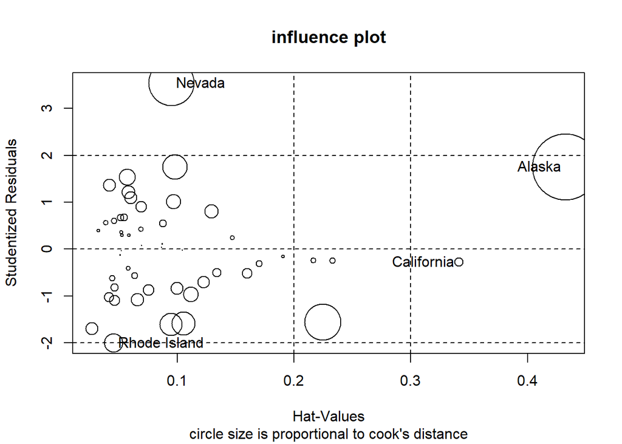

```
##                 StudRes        Hat       CookD
## Alaska        1.7536917 0.43247319 0.448050997
## California   -0.2761492 0.34087628 0.008052956
## Nevada        3.5429286 0.09508977 0.209915743
## Rhode Island -2.0001631 0.04562377 0.035858963
```

```r
influencePlot(lm.fit3.1.3,id.method="identify",main="influence plot",sub="circle size is proportional to cook's distance")
```

**结果解读：**纵坐标看离群点(>2或<-2),横坐标看高杠杆值点（>0.2或0.3），圈圈大小看对模型参数估计的影响大小，太大的可能是强影响点。从图中看到三种点均有存在

### 4.2 离群点

方法1：通过Q-Q图，落在置信区间外的是离群点

方法2：标准化残差值>2或<-2的可能是离群点

**方法3：**

```r
#下面这个函数，是通过！单个！最大（—or+）残差值的显著性来判断是否具有离群点，如果不显著，就说明没有离群点，如果显著，必须删除这个离群点，然后再次使用这个函数用来判断是不是还有其他离群点的存在
outlierTest(lm.fit3.1.3)
```

```
##        rstudent unadjusted p-value Bonferonni p
## Nevada 3.542929         0.00095088     0.047544
```

### 4.3 高杠杆值点

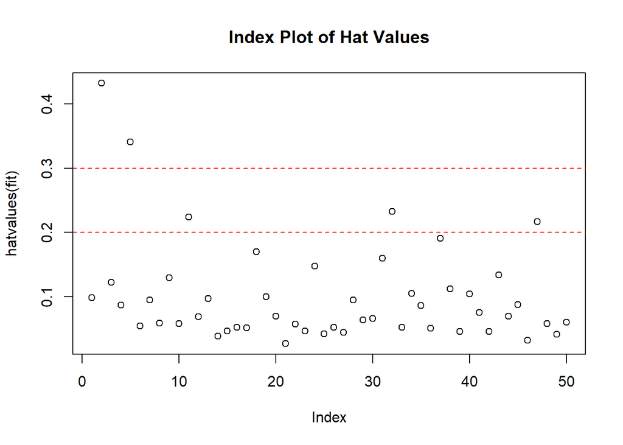

```
## integer(0)
```

```r
hatplot <- function(fit)
{
    p <- length(coefficients(fit)) #p是参数个数
    n <- length(fitted(fit))#n是样本量
    plot(hatvalues(fit), main = "Index Plot of Hat Values")
    abline(h = c(2, 3) * p / n, col = "red", lty = 2)
    identify(1:n, hatvalues(fit), names(hatvalues(fit)))#定位函数
}
hatplot(lm.fit3.1.3)
```

**结果解读：**只需要看图，水平线标注的是帽子均值2倍和3倍的位置，一般认为超过帽子均值2倍和3倍的位置的点是高杠杆值点。

### 4.4 强影响值点

**方法1：计算Cook距离并绘图**（Cook’s D图）（该图对于找强影响点很有用，但是不能反映这些点是怎么影响模型的）((这个图可以直接显示出来强影响点的名字))

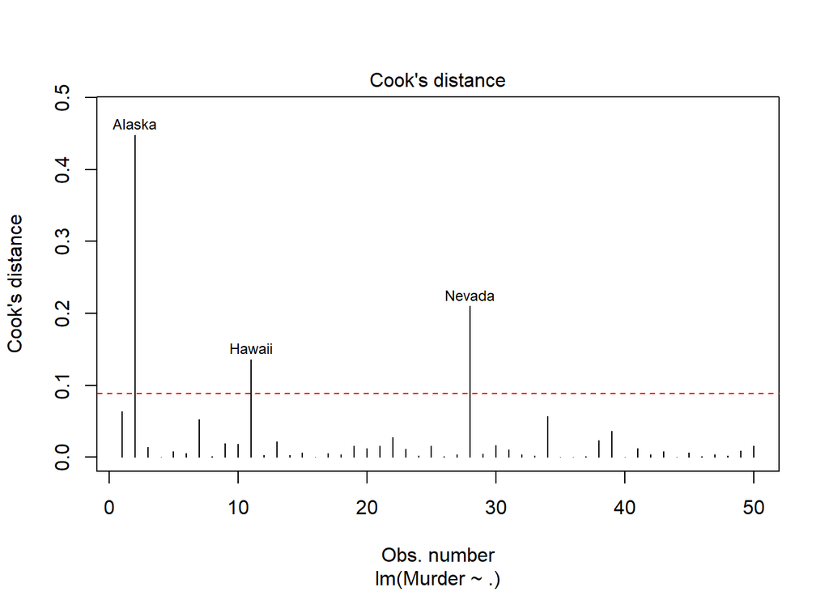

```r
cutoff <- 4 / (nrow(states) - (length(lm.fit3.1.3$coefficients) - 1) - 1)
plot(lm.fit3.1.3, which = 4, cook.levels = cutoff)#？which=4表示前面的第四张图，但是第4张图并不是这样的(而且第1，2，3张图是一样的)#这里好像有点疑问
abline(h = cutoff, lty = 2, col = "red")
```

**结果解读：**从图中可以看到有三个强影响点（已被标出名字）

**方法2：绘制变量添加图**

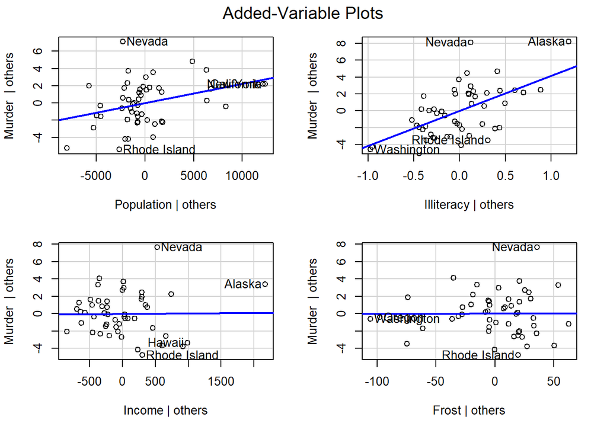

```r
avPlots(lm.fit3.1.3,id.method="identify")
```

**结果解读：**变量添加图是，预测变量$X_k$与其余k-1个预测变量拟合的残差值（X轴）与响应变量Y与其余k-1个预测变量拟合的残差值（Y轴）画出的散点关系图，还给出了平滑拟合曲线。图中的直线表示相应预测变量的实际回归系数。如左下和右下两个图，直线为水平在O处，说明这两个预测变量是不显著的，最终的回归模型中，这两个变量前的系数应该是0。

## 5 问题的解决

### 5.1 违反线性性假设

```r
boxTidwell(Murder ~ Population + Illiteracy, data = states)
```

```
##            MLE of lambda Score Statistic (z) Pr(>|z|)
## Population       0.86939             -0.3228   0.7468
## Illiteracy       1.35812              0.6194   0.5357
##
## iterations =  19
```

**结果解读：**结果表明使用变换，可以改善线性关系，但是由于计分检验的P值都>0.05，所以不能拒绝原假设，意味着不需要进行该变量变换

### 5.2 违反正态性假设

```r
summary(powerTransform(states$Murder))
```

```
## bcPower Transformation to Normality
##               Est Power Rounded Pwr Wald Lwr Bnd Wald Upr Bnd
## states$Murder    0.6055           1       0.0884       1.1227
##
## Likelihood ratio test that transformation parameter is equal to 0
##  (log transformation)
##                            LRT df     pval
## LR test, lambda = (0) 5.665991  1 0.017297
##
## Likelihood ratio test that no transformation is needed
##                            LRT df    pval
## LR test, lambda = (1) 2.122763  1 0.14512
```

**结果解读：**结果表明，用murder^0.6来正态化变量murder，但是发现不能拒绝lambda=1的假设，意味着，不需要进行该变量变换

### 5.4 存在多重共线性

方法2：在多项式回归模型中，把任意给定的自变量表示成与其均值离差的形式，以大大降低一阶，二阶和更高阶的项之间的多重共线性

方法3：岭回归（专门处理多重共线性）((下次再讲))

方法4：主成分回归（参考《应用回归分析》何晓群，刘文卿）、因子分析这些

### 5.5 存在异常值点

如果能肯定地说明一个异常观察值是很大的测量误差的结果，剔除是合适的

如果异常观察值是准确的，他可能意味着模型的失败（遗漏重要自变量或选择了不正确的函数形式）

如果异常观察值是准确的，但找不到对于他的解释，那么可以抑制他的影响（而不是剔除）（（比如使用最小绝对离差法：通过极小化绝对离差之和来估计回归系数。这种方法具有对 异常数据和不合适模型并不敏感的性质，除了这个方法，还有其他稳健的方法可以参考《统计稳健性：关于当代应用问题的看法》罗伯特.V.霍格））

## 6 补充（待补充）

### 6.1 库克距离（待补充）

### 6.2 帽子矩阵（待补充）

### 6.3 异常值点的区分（待补充）